# GLM para dados contínuos

Niege Felix & Samuel Lima

# 1 O que é um dado contínuo?

Em estatística, dados contínuos são aqueles que podem assumir qualquer valor dentro de um intervalo, incluindo números fracionários ou decimais. Eles surgem de medidas, e não de contagens, e teoricamente existem infinitos valores possíveis entre dois pontos quaisquer do intervalo.

- Ex. Número fracionário (e.g., 1.59, 310.89, 0.034, …)

# 2 Características principais dos dados contínuos:

## 2.1 Infinitos valores possíveis:

Entre dois valores quaisquer, sempre é possível encontrar outro valor. Ex.: Entre 1,5 e 1,6, há infinitos valores como 1,51, 1,512, 1,5123 etc.

## 2.2 Medidos, não contados:

Normalmente obtidos por instrumentos de medição. Ex.: altura, peso, temperatura, tempo, pressão arterial.

## 2.3 Representação:

```
Podem ser representados com números decimais e geralmente são analisados com estatísticas descritivas como média, desvio-padrão e variância.
```

Exemplo:

- Altura de uma pessoa: 1,73 m, 1,732 m, 1,7321 m…
- Temperatura de uma sala: 23,5 °C, 23,55 °C, 23,555 °C…

# 3 Distribuições de probabilidade contínuas:

- Gaussiana (Normal)
- log-Gaussiana
- Gama
- Exponencial
- Qui-Quadrado
- Student
- Uniforme*
- Beta*
- Weibull*

# 4 Distribuição log-Normal

A distribuição log-normal é uma distribuição contínua usada para modelar variáveis positivas cujo logaritmo segue uma distribuição normal. Ou seja, se 𝑌é log-normal, então ln(Y) é normalmente distribuído. É um tipo de Modelo Linear Generalizado (Generalized Linear Model) usado para dados contínuos positivos e assimétricos à direita.

O GLM log-Normal é aplicado quando:

- A variável resposta Y > 0;
- O logaritmo da resposta tem comportamento aproximadamente normal.

Estrutura do modelo: ln  (Y𝑖) =𝛽0 +𝛽1𝑥1𝑖+𝛽2𝑥2𝑖+…+𝜖𝑖,𝜖𝑖∼𝑁(0,𝜎2)

ln(Yi)=β0+β1x1i+β2x2i+…+ϵi,ϵi∼N(0,σ2)

# 5 Função de ligação e características

- Função de ligação: logarítmica (𝑔(𝜇)=log(𝜇)
- Domínio da variável resposta: Y>0
- Assimetria: positiva
- Variação: aumenta com a média

# 6 Pressuposto de uma distribuição log-Normal:

- Os valores de 𝑌são positivos e contínuos;
- O logaritmo de Y tem distribuição Normal;
- A variância de 𝑌 cresce com o quadrado da média (heterocedasticidade natural);
- As observações são independentes;
- O modelo é linear nos parâmetros no espaço transformado (log).

# 7 Use um GLM log-Normal quando:

- Seus dados são positivos e assimétricos;
- A transformação logarítmica normaliza os resíduos;
- Você quer modelar diretamente no escopo multiplicativo (ex.: taxas, crescimento, biomassa, decomposição etc.).

# 8 Um modelo log-Normal pode ser ajustado de duas formas:

- Transformar e usar modelo linear;
- Usar glm() com família gaussiana e link log.

# 9 Prática no R | Relatório:

Usamos o banco de dados `fisheries.rds`, com o **objetivo** de: Testar se a Captura por unidade de esforço (CPUE) dos atuns no oceano atlântico é influenciada pelos meses, assim como a latitude e longitude.

Carregando os pacotes e importando os dados

```r
library(ggplot2) #Define um conj. de princípios para construir gráficos de forma sistemática.
library(MASS) # faz a seleção automática de modelos
library(dplyr) # seleciona, filtra, ordena, resume e modifica dados em tabelas.
library(DHARMa) # serve para avaliar se o modelo ajustado está adequado aos dados apresentados.
library(ggeffects) # para plotar os resultados
library(performance) #avaliação dos residuos
library(GGally)

dados <- readRDS("../Dados/fisheries.rds")
```

Explorando os dados

```r
str(dados) # Um resumo do conteúdo de cada variável, tipo de variável, n de observações e etc;
```

```
## 'data.frame':    476 obs. of  33 variables:
##  $ Ano                     : int  2003 2003 2003 2003 2003 2003 2003 2003 2003 2003 ...
##  $ Mes                     : int  1 1 1 1 1 1 1 1 1 1 ...
##  $ N_anzol                 : int  1050 1050 1050 1050 1050 980 955 960 960 1052 ...
##  $ Barco                   : chr  "V201" "V201" "V201" "V201" ...
##  $ Pais                    : Factor w/ 3 levels "A","B","C": 2 2 2 2 2 2 2 2 2 2 ...
##  $ Long                    : num  -33.3 -38.8 -38.1 -35.8 -36.9 ...
##  $ Lat                     : num  -27.855 0.399 -15.695 -1.997 -19.667 ...
##  $ Thunnus_albacares       : num  4 27 5 55 7 11 29 58 6 14 ...
##  $ Thunnus_atlanticus      : num  0 32 0 0 4 18 0 0 4 13 ...
##  $ Katsuwonus_pelamis      : num  5 0 7 0 5 0 36 0 0 7 ...
##  $ Xiphias_gladius         : num  0 0 0 0 0 0 0 0 2 0 ...
##  $ Istiophorus_albicans    : num  3 0 0 11 0 5 0 12 3 0 ...
##  $ Tetrapturus_albidus     : num  3 6 0 0 2 7 0 0 2 0 ...
##  $ Makaira_nigricans       : num  0 0 0 0 0 0 0 0 0 0 ...
```

[output cut: 19 more lines]

Transformando as variáveis e selecionando espécies alvo

```r
# character -> vector
dados[, c("Ano", "Mes", "Barco")] <- lapply(dados[, c("Ano", "Mes", "Barco")], factor)


# Espécies alvo (atuns)
especies_alvo <- c("Thunnus_albacares",
                   "Thunnus_atlanticus",
                   "Katsuwonus_pelamis",
                   "Prionace_glauca")
```

Número de espécies não-alvo:

```r
especies_nalvo <- setdiff(colnames(dados)[8:27], especies_alvo)
length(especies_nalvo) #No. de espécies que não são alvo da pesca
```

```
## [1] 16
```

Calculando a abundância total de espécies alvo e padronizando a abundância pelo esforço amostral (CPUE - Catch per unit of effort)

```r
dados <- dados %>%
         rowwise() %>%  # analisa linha por linha
         mutate(Catch = sum(c_across(all_of(especies_alvo))),
                CPUE = Catch/N_anzol) %>%
         data.frame()
```

# 10 Visualizando os dados

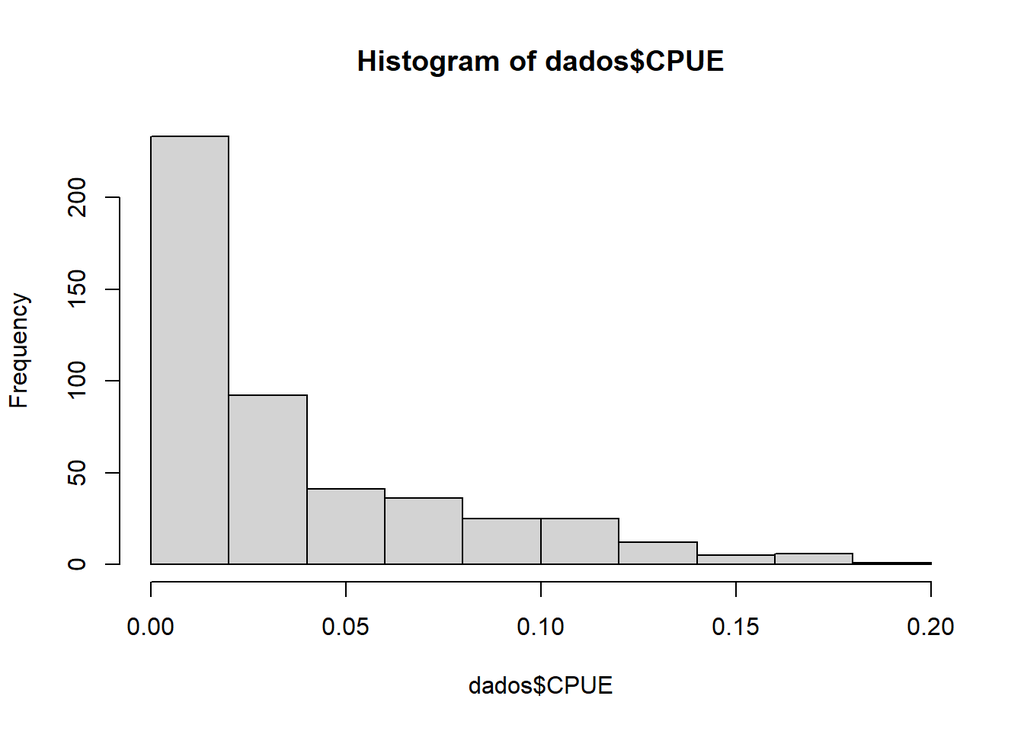

```r
hist(dados$CPUE)
```

```r
summary(dados$CPUE)
```

```
##    Min. 1st Qu.  Median    Mean 3rd Qu.    Max.
## 0.00000 0.01273 0.02091 0.03873 0.05528 0.18046
```

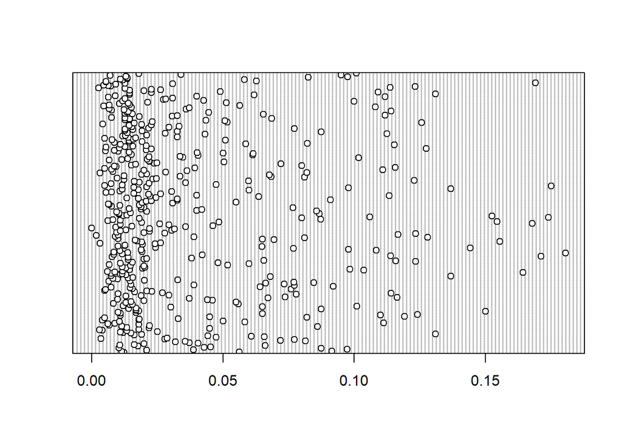

```r
dotchart(dados$CPUE)
```

## 10.1 Dinâmica temporal

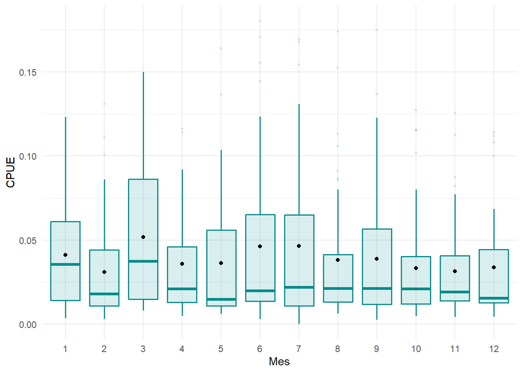

```r
ggplot(dados, aes(x = Mes, y = CPUE)) +
#ggplot(dados, aes(x = Mes, y = log1p(CPUE))) +
  geom_boxplot(size = 0.7, fill = 'cyan4',col = 'cyan4', alpha = 0.15) +
  stat_summary(fun = mean, geom="point", shape=19, size=1.5, color="black") +
  theme_minimal()
```

## 10.2 Dinâmica espacial

### 10.2.1 Latitude

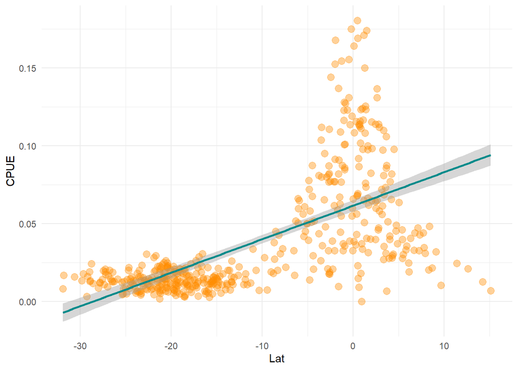

```r
ggplot(dados, aes(x = Lat, y = CPUE)) +
#ggplot(dados, aes(x = Lat, y = log1p(CPUE))) +
  geom_point(size = 3, col = 'darkorange', alpha = 0.4) +
  geom_smooth(method = "lm", col = 'cyan4') +
  theme_minimal()
```

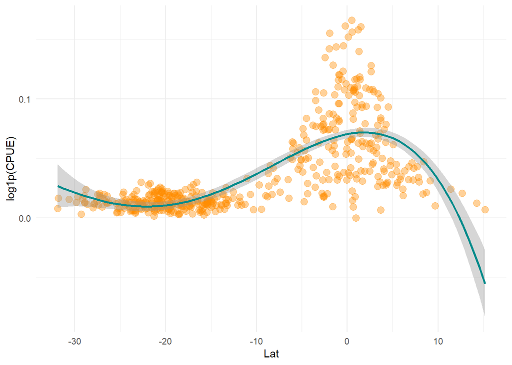

```r
ggplot(dados, aes(x = Lat, y = log1p(CPUE))) +
  geom_point(size = 3, col = 'darkorange', alpha = 0.4) +
  geom_smooth(method = "lm", col = 'cyan4',formula = y ~ poly(x,4)) +
  theme_minimal()
```

Longitude

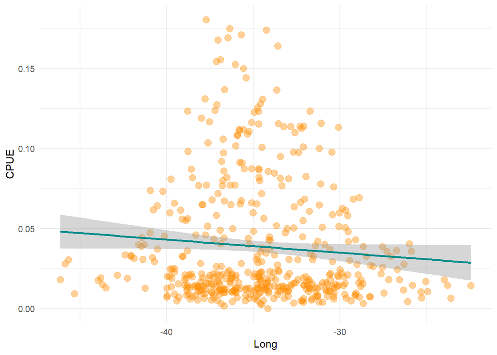

```r
ggplot(dados, aes(x = Long, y = CPUE)) +
  #ggplot(dados, aes(x = Long, y = log1p(CPUE))) +
  geom_point(size = 3, col = 'darkorange', alpha = 0.4) +
  geom_smooth(method = "lm", col = 'cyan4') +
  theme_minimal()
```

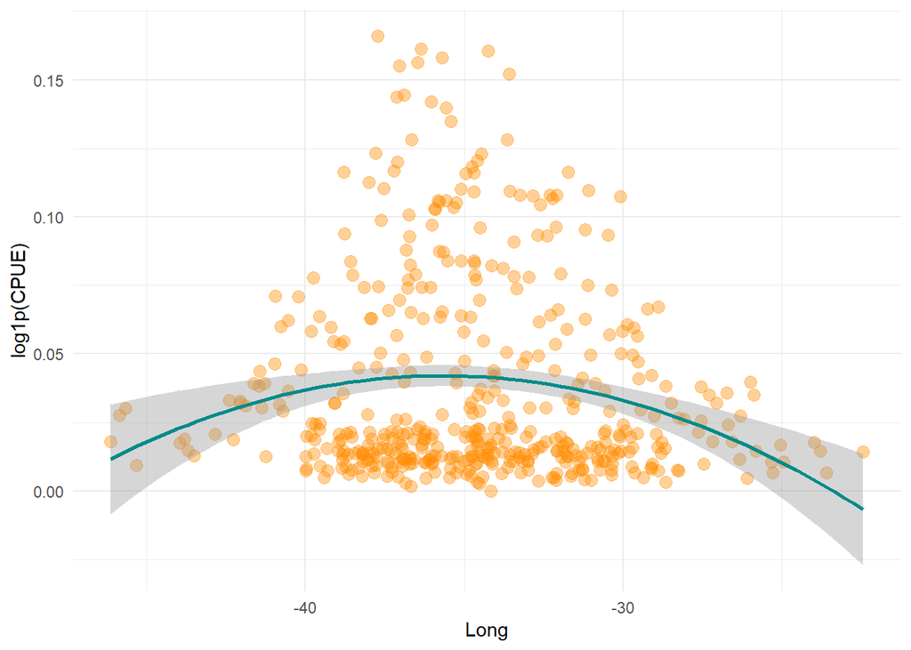

```r
ggplot(dados, aes(x = Long, y = log1p(CPUE))) +
   geom_point(size = 3, col = 'darkorange', alpha = 0.4) +
   geom_smooth(method = "lm", col = 'cyan4', formula = y ~ poly(x,2)) +
   theme_minimal()
```

Aparentemente a latitude se adequa mais a uma função polinomial à quarta e a longitude a uma função polinomial quadrática

Modelando CPUE Preparando os dados:

- Lembrando que a distribuição Gama e log-Normal é para variáveis estritamente positivas.
- Isso implica que a variável resposta não pode conter o valor 0.
- Truqe matemátcio: adicionar uma pequena constante

Usando 10% da mediana do CPUE

```r
dados$CPUE2 <- dados$CPUE + (0.1 * median(dados$CPUE))

# Transformando para log
dados$CPUE2_log <- log(dados$CPUE2)
```

## 10.3 Escalando as variáveis preditoras e verificando correlação

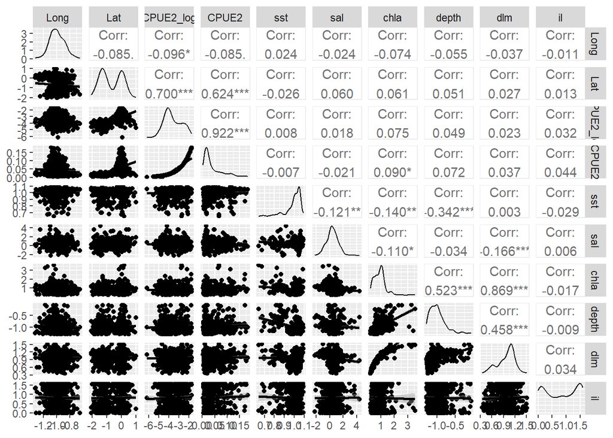

```r
cols<-c("Lat","Long","sst","sal","chla","depth","dlm","il")
dados[,cols] <- scale(dados[,cols], scale=T, center=F)

ggpairs(dados,
        columns = c(6,7,37,36,28:33),
        lower = list(continuous = "smooth"))
```

Entre as variáveis preditoras contínuas estão altamente correlacionadas apenas chla e dlm. Não vamos utilizá-las juntas no mesmo modelo

Rodando os modelos

Modelo Gama

```r
modelo_G <- glm(CPUE2 ~ poly(Lat,4) * poly(Long,2) +Mes+sst+sal+chla+depth+il,
                family = Gamma(link = "log"),
                data = dados)

modelo_G2 <- glm(CPUE2 ~ poly(Lat,4) + poly(Long,2) + Mes+sst+sal+chla+depth+il,
                 family = Gamma(link = "log"),
                 data = dados)
```

Modelo log-Normal

```r
modelo_LN <- glm(CPUE2_log ~ poly(Lat,4) * poly(Long,2) + Mes + sst + sal + chla + depth + il,
                 family = gaussian,
                 data = dados)

modelo_LN2 <- glm(CPUE2_log ~ poly(Lat,4) + poly(Long,2) + Mes + sst + sal + chla + depth + il,
                 family = gaussian,
                 data = dados)
```

Avaliando os modelos através do AIC: O menor AIC indica o melhor modelo.

```r
AIC(modelo_G, modelo_G2, modelo_LN, modelo_LN2)
```

```
##            df        AIC
## modelo_G   32 -2820.9554
## modelo_G2  24 -2748.6642
## modelo_LN  32   649.3789
## modelo_LN2 24   704.8483
```

Teste de razão de verossimilhança entre os dois melhores modelos

```r
lmtest::lrtest(modelo_G,modelo_G2) ## Quanto maior o valor de logLik, melhor o ajuste!
```

```
## Likelihood ratio test
##
## Model 1: CPUE2 ~ poly(Lat, 4) * poly(Long, 2) + Mes + sst + sal + chla +
##     depth + il
## Model 2: CPUE2 ~ poly(Lat, 4) + poly(Long, 2) + Mes + sst + sal + chla +
##     depth + il
##   #Df LogLik Df  Chisq Pr(>Chisq)
## 1  32 1442.5
## 2  24 1398.3 -8 88.291  1.033e-15 ***
## ---
## Signif. codes:  0 '***' 0.001 '**' 0.01 '*' 0.05 '.' 0.1 ' ' 1
```

Verificando a deviância entre os dois melhores modelos

```r
modelo_G$deviance
```

```
## [1] 81.96987
```

```r
modelo_G2$deviance
```

```
## [1] 98.12108
```

A Deviância é uma medida de erro ou ajuste do modelo.

Fórmula: Deviância = 2×(log-verossimilhança do modelo saturado −log-verossimilhança do modelo ajustado)

- O modelo saturado é um modelo “perfeito”, que prevê exatamente cada observação (erro = 0).
- O modelo ajustado é o modelo que você realmente construiu.

Assim, quanto menor a deviância, melhor o modelo se ajusta aos dados.

> Seguimos com o nosso primeiro modelo!

Verificando o ajuste dos resíduos do melhor modelo

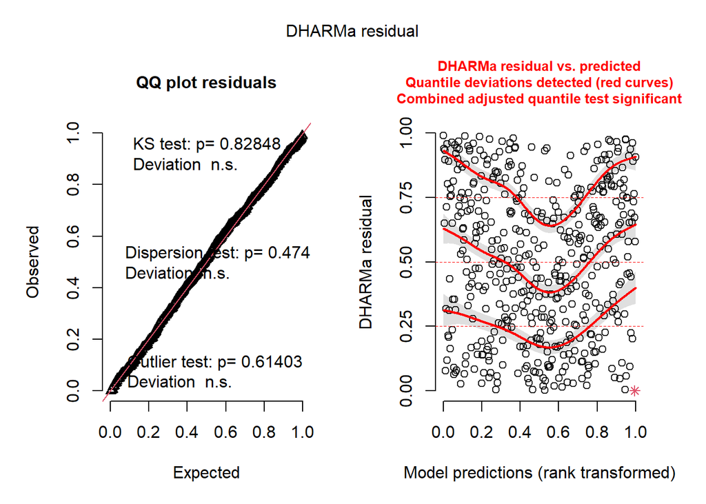

```r
resG <- simulateResiduals(modelo_G, n=1000, plot = T)
```

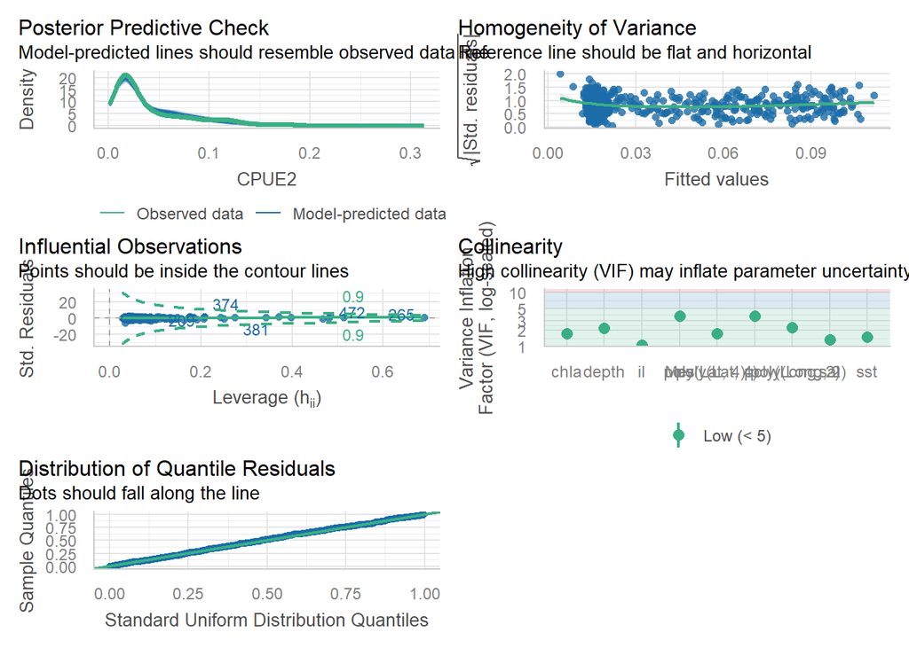

```r
check_model(resG)
```

Os resíduos ficaram relativamente bem ajustados. Acreditamos que um ajuste melhor não é possível provavelmente devido a relação com a latitude e longitude não serem lineares.

## 10.4 Avaliando os resultados:

```r
summary(modelo_G)
```

```
##
## Call:
## glm(formula = CPUE2 ~ poly(Lat, 4) * poly(Long, 2) + Mes + sst +
##     sal + chla + depth + il, family = Gamma(link = "log"), data = dados)
##
## Coefficients:
##                                Estimate Std. Error t value Pr(>|t|)
## (Intercept)                   -3.753984   0.284963 -13.174  < 2e-16 ***
## poly(Lat, 4)1                 13.763406   0.419225  32.831  < 2e-16 ***
## poly(Lat, 4)2                 -0.792514   0.416175  -1.904  0.05752 .
## poly(Lat, 4)3                 -6.947917   0.434990 -15.973  < 2e-16 ***
## poly(Lat, 4)4                 -1.962494   0.463915  -4.230 2.84e-05 ***
## poly(Long, 2)1                -1.436366   0.480625  -2.989  0.00296 **
## poly(Long, 2)2                -3.865377   0.530806  -7.282 1.50e-12 ***
## Mes2                          -0.095205   0.101209  -0.941  0.34738
## Mes3                           0.051859   0.107229   0.484  0.62889
## Mes4                           0.082768   0.105702   0.783  0.43403
## Mes5                          -0.021176   0.111815  -0.189  0.84988
## Mes6                           0.126767   0.101728   1.246  0.21337
## Mes7                           0.104107   0.101884   1.022  0.30742
## Mes8                           0.043302   0.099752   0.434  0.66442
## Mes9                           0.074691   0.098150   0.761  0.44706
## Mes10                         -0.004486   0.098893  -0.045  0.96384
## Mes11                          0.044917   0.099002   0.454  0.65027
## Mes12                          0.035581   0.103961   0.342  0.73232
## sst                            0.198112   0.294547   0.673  0.50155
## sal                            0.002548   0.023681   0.108  0.91438
## chla                           0.012170   0.055052   0.221  0.82515
## depth                         -0.005894   0.114689  -0.051  0.95904
## il                             0.018380   0.033328   0.551  0.58157
## poly(Lat, 4)1:poly(Long, 2)1  -4.703326   9.766599  -0.482  0.63035
## poly(Lat, 4)2:poly(Long, 2)1  17.467534   9.678273   1.805  0.07178 .
## poly(Lat, 4)3:poly(Long, 2)1  15.785785  11.931012   1.323  0.18649
## poly(Lat, 4)4:poly(Long, 2)1  17.149884  12.464572   1.376  0.16955
## poly(Lat, 4)1:poly(Long, 2)2 -78.917672   9.551920  -8.262 1.66e-15 ***
## poly(Lat, 4)2:poly(Long, 2)2   7.162147  10.282446   0.697  0.48645
## poly(Lat, 4)3:poly(Long, 2)2  35.836678  12.336093   2.905  0.00386 **
## poly(Lat, 4)4:poly(Long, 2)2 -22.678561  14.194377  -1.598  0.11082
## ---
## Signif. codes:  0 '***' 0.001 '**' 0.01 '*' 0.05 '.' 0.1 ' ' 1
##
## (Dispersion parameter for Gamma family taken to be 0.1625005)
##
##     Null deviance: 367.02  on 475  degrees of freedom
## Residual deviance:  81.97  on 445  degrees of freedom
## AIC: -2821
##
## Number of Fisher Scoring iterations: 22
```

A princípio, observamos que a latitude e a longitude influenciam de forma interativa a captura por unidade de esforço dos atuns e que o sentido desse efeito varia de positivo a negativo. Para facilitar, vamos observar graficamente o predito pelo modelo:

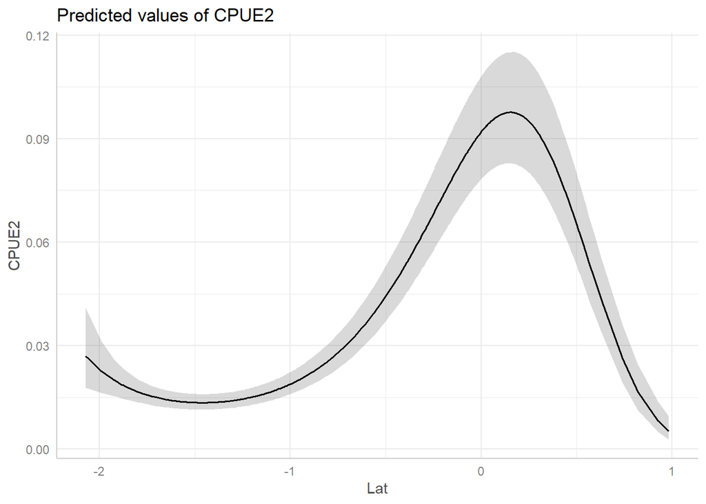

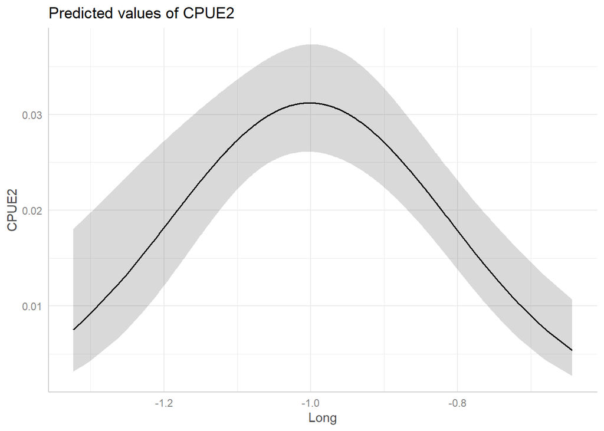

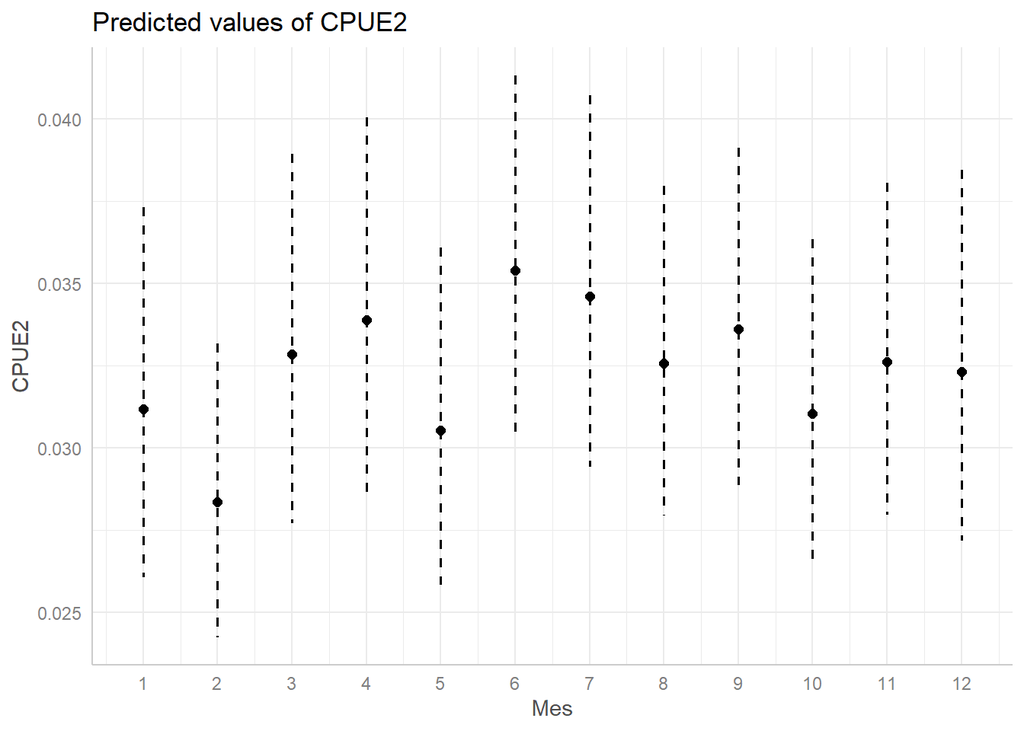

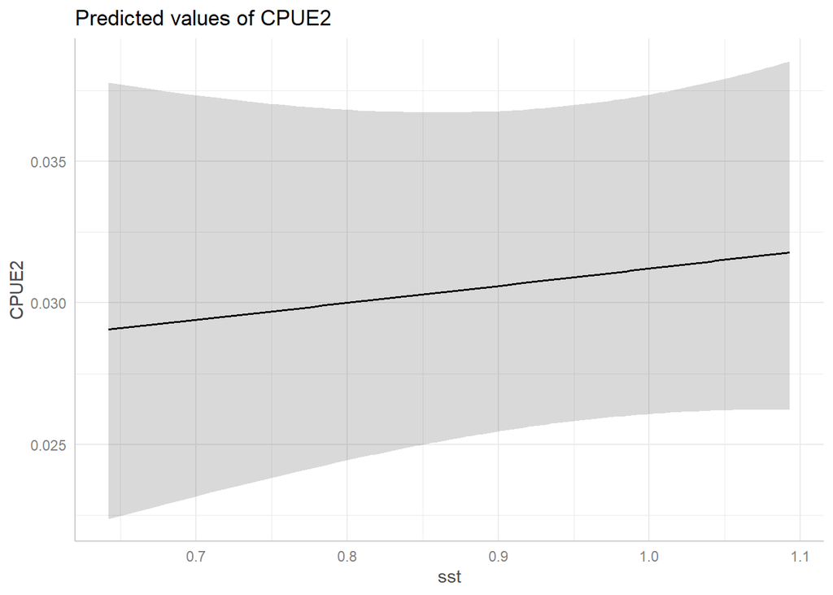

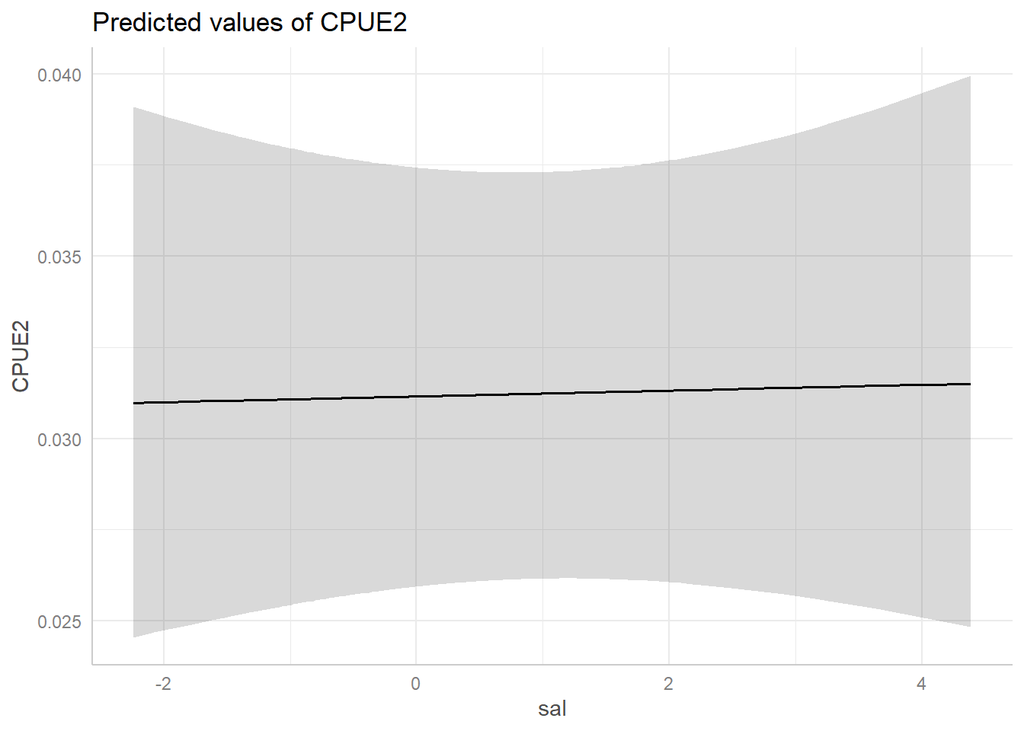

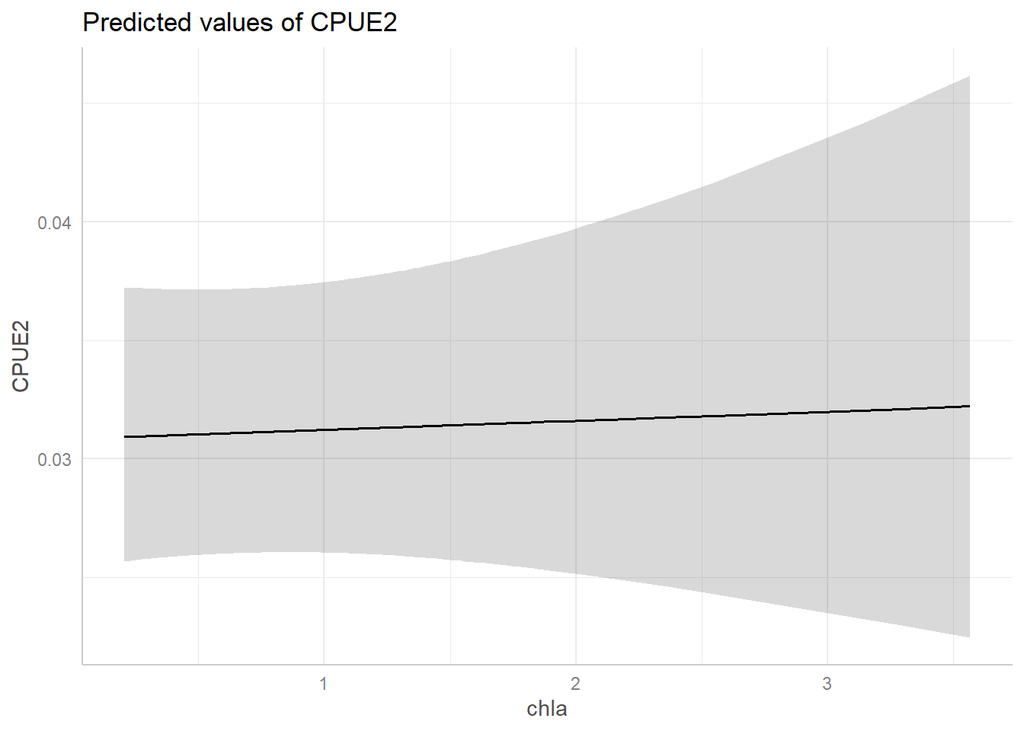

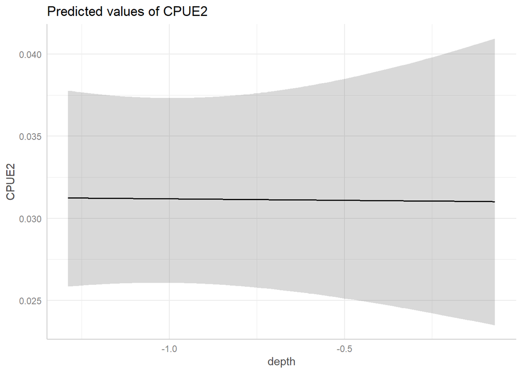

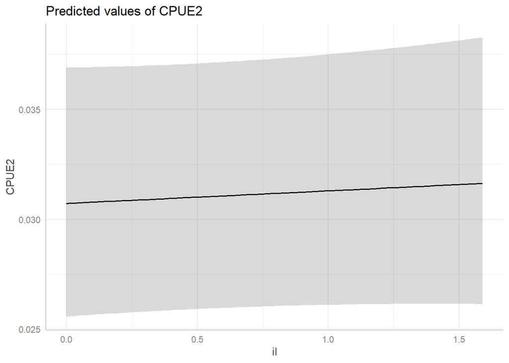

```r
ggpredict(modelo_G) %>% plot()
```

Dessa forma conseguimos observar que quanto maior a latitude, maior a captura de atuns. Porém, somente até os trópicos. Após os 5° de latitude há uma redução da captura. Da mesma forma, a captura de atuns aumenta até -35° de longitude e logo em seguida diminui.

Lembrando que a significância da interação nos diz que o efeito da latitude depende da longitude e vice-versa. Portanto, provavelmente há uma maior captura de atuns nos trópicos, principalmente nos locais próximos de -35° de longitude.